# Analiza ofert dotyczących wynajmu nieruchomości z portalu gumtree.pl

Krzysztof Słomczyński

# Dlaczego taki temat?

Chciałem znaleźć taki temat, którego choć część wykonania będzie miała wymiar praktyczny. Na grupie [MI^2](http://mi2.mini.pw.edu.pl) składającej się głównie ze studentów i absolwentów MiNI PW i MIM UW funkcjonuje projekt CzasDojazdu. Ma on na celu dostarczenie aplikacji wyszukującej w Warszawie pokojów do wynajęcia pod kątem kryterium czasu dojazdu z mieszkania do pracy. Przeglądając go zauważyłem, że część danych pobieranych z portalu gumtree.pl jest błędnie zapisywanych (metraż), niektóre zaś są zupełnie pomijane (czy można palić lub trzymać zwierzęta, jaka jest preferowana płeć). Postanowiłem udoskonalić scraper funkcjonujący w tym projekcie, a na świeżo pobranych danych spróbowac zbudować model przewidujący ceny wynajmowanych pokoi.

## Udoskonalenie scrapera - zdobycie danych

Z pomocą pakietu `rvest` oraz wtyczki [SelectorGadget](http://selectorgadget.com) działającej w przeglądarce Chromium udało mi się wydobyć ze stron z ofertami interesujące mnie dane. Kod znaduje się w repozytorium projektu CzasDojazdu. Kolejne rejestry zapisywane są w bazie danych SQLite. Ponieważ wdrożenie kodu na produkcję ze względów organizacyjnych w takich projektach nieco trwa, zdecydowałem się na przerobienie go tak, aby dane zapisywane były do plików *.csv. Przypatrując się pobranym ofertom wiedziałem, że ich liczba przez czas realizacji projektu nie urośnie do dużych rozmiarów.

# Przygotowanie do projektu

W ramach przygotowania się do realizacji projektu ukończyłem dwa kursy.

- Machine Learning at Coursera by Andrew Ng
- Statistical Learning at Stanford ONLINE by Trevor Hastie and Robert Tibshirani

Oraz zapoznałem się z takimi narzędziami jak Crontab, Flume, Hadoop HDFS i Spark (pakiet `sparklyr`).

# Obróbka danych

```r
# Ładowanie bibliotek
library(dplyr)
library(readr)
library(stringi)
library(knitr)
library(pander)
```

Oferta dotycząca pokoju do wynajęcia na portalu gumtree.pl może zawierać następujące (powtarzalne) opcje wyboru:

1. Lokalizacja
- Miasto, Województwo
- Dokładny adres
2. Do wynajęcia przez
- “———”
- Właściciel
- Agencja
3. Współdzielenie
- Współdzielenie pokoju
- Współdzielenie mieszkania/domu
4. Dostępny
- Data w formacie %d/%m/%Y
5. Rodzaj nieruchomości
- “———”
- Mieszkanie
- Dom
- Inne
6. Wielkość (m2)
- Liczba typu Integer
7. Liczba pokoi
- “———”
- Kawalerka lub garsoneria
- 2 pokoje
- 3 pokoje
- 4 pokoje
- 5 pokoi
- 6 lub więcej pokoi
8. Palący
- “———”"
- Tak
- Nie
9. Przyjazne zwierzakom
- “———”"
- Tak
- Nie
10. Preferowana płeć
- “———”
- Mężczyzna
- Kobieta
- Bez preferencji
11. Cena
- Liczba typu Integer
- Proszę o kontakt
- Wymiana/zamiana

Zbierane są też dane dotyczące daty dodania oferty, link do ogłoszenia, opis i tutuł. Te jednak tym razem nie będą nas interesować ze względu na swój unikalny charakter.

Przyjrzyjmy się im nieco bliżej.

```r
# Ładowanie danych
dane1 <- read_csv("2016-10-26df.csv")
dane2 <- read_csv("2016-11-17df.csv")
pokoje <- rbind(dane1, dane2) %>% distinct()
rm(dane1, dane2)
```

```r
# Dane pod lupą - obróbka
dim(pokoje)
```

```
[1] 9321   16
```

```r
str(pokoje)
```

```
Classes ‘tbl_df’, ‘tbl’ and 'data.frame':   9321 obs. of  16 variables:
 $ data_dodania        : chr  "01/10/2016" "01/10/2016" "01/10/2016" "01/10/2016" ...
 $ lokalizacja         : chr  "Białołęka, Warszawa" "Bielany, Warszawa" "Bielany, Warszawa" "Bydgoszcz, Kujawsko - pomorskie" ...
 $ href                : chr  "https://www.gumtree.pl/a-pokoje-do-wynajecia/bialoleka/pokoje-pracownicze-noclegi-pracownicze-dla-firm+-kwatery/100168743856091"| __truncated__ "https://www.gumtree.pl/a-pokoje-do-wynajecia/bielany/pok%C3%B3j-dla-studentki-uksw-wat-awf-uw-od-pa%C5%BCdziernika/100179124…
 $ opis                : chr  "Ofertę swoją kierujemy zarówno do dużych firm jak i indywidualnych grup, które wykonują różnego rodzaju prace w Warszawie lub o"| __truncated__ "Wynajme pokój umeblowany/kanapa ikea, szafa, biurko/Do metra stare bielany jest 5 minut.W mieszkaniu jest nowa pralka bosch,…
 $ adres               : chr  "Bryły 42" NA "Bielany, Warszawa, Polska" "Gdańska" ...
 $ cena                : chr  "12 zł" "1 000 zł" "Proszę o kontakt" "400 zł" ...
 $ tytuł               : chr  "Pokoje pracownicze, noclegi pracownicze dla firm- kwatery" "POKÓJ DLA STUDENTKI UKSW, WAT, AWF, UW OD PAŻDZIERNIKA!!!!!!!!!!!!" "Duży pokój  w pobliżu metra" "Pokoje po remoncie w centrum miasta" ...
 $ do_wynajęcia_przez  : chr  "Właściciel" "Właściciel" "Właściciel" "Właściciel" ...
 $ współdzielenie      : chr  "Współdzielenie pokoju" "Współdzielenie mieszkania/domu" "Współdzielenie mieszkania/domu" "Współdzielenie pokoju" ...
 $ wielkość_(m2)       : int  NA 80 59 17 NA 25 12 20 80 27 ...
 $ liczba_pokoi        : chr  NA "4 pokoje" "2 pokoje" "3 pokoje" ...
 $ rodzaj_nieruchomości: chr  "Dom" "Mieszkanie" "Mieszkanie" "Mieszkanie" ...
 $ preferowana_płeć    : chr  NA "Kobieta" "Bez preferencji" "Bez preferencji" ...
 $ palący              : chr  NA "Nie" "Nie" "Nie" ...
 $ przyjazne_zwierzakom: chr  NA "Nie" "Nie" "Nie" ...
 $ dostępny            : chr  NA "01/10/2016" "01/10/2016" "03/10/2016" ...
 - attr(*, "spec")=List of 2
  ..$ cols   :List of 16
  .. ..$ data_dodania        : list()
  .. .. ..- attr(*, "class")= chr  "collector_character" "collector"
  .. ..$ lokalizacja         : list()
  .. .. ..- attr(*, "class")= chr  "collector_character" "collector"
  .. ..$ href                : list()
  .. .. ..- attr(*, "class")= chr  "collector_character" "collector"
  .. ..$ opis                : list()
  .. .. ..- attr(*, "class")= chr  "collector_character" "collector"
  .. ..$ adres               : list()
  .. .. ..- attr(*, "class")= chr  "collector_character" "collector"
  .. ..$ cena                : list()
  .. .. ..- attr(*, "class")= chr  "collector_character" "collector"
  .. ..$ tytuł               : list()
  .. .. ..- attr(*, "class")= chr  "collector_character" "collector"
  .. ..$ do_wynajęcia_przez  : list()
  .. .. ..- attr(*, "class")= chr  "collector_character" "collector"
  .. ..$ współdzielenie      : list()
  .. .. ..- attr(*, "class")= chr  "collector_character" "collector"
  .. ..$ wielkość_(m2)       : list()
  .. .. ..- attr(*, "class")= chr  "collector_integer" "collector"
  .. ..$ liczba_pokoi        : list()
  .. .. ..- attr(*, "class")= chr  "collector_character" "collector"
  .. ..$ rodzaj_nieruchomości: list()
  .. .. ..- attr(*, "class")= chr  "collector_character" "collector"
  .. ..$ preferowana_płeć    : list()
  .. .. ..- attr(*, "class")= chr  "collector_character" "collector"
  .. ..$ palący              : list()
  .. .. ..- attr(*, "class")= chr  "collector_character" "collector"
  .. ..$ przyjazne_zwierzakom: list()
  .. .. ..- attr(*, "class")= chr  "collector_character" "collector"
  .. ..$ dostępny            : list()
  .. .. ..- attr(*, "class")= chr  "collector_character" "collector"
  ..$ default: list()
  .. ..- attr(*, "class")= chr  "collector_guess" "collector"
  ..- attr(*, "class")= chr "col_spec"
```

Z dostępnych kolumn pozostawimy te które są unikalne. Dodatkowo skorzystamy jednak z opisów w celu policzenia ilości występujacych w nich słów.

```r
pokoje %>% names()
```

```
 [1] "data_dodania"         "lokalizacja"          "href"                 "opis"
 [5] "adres"                "cena"                 "tytuł"                "do_wynajęcia_przez"
 [9] "współdzielenie"       "wielkość_(m2)"        "liczba_pokoi"         "rodzaj_nieruchomości"
[13] "preferowana_płeć"     "palący"               "przyjazne_zwierzakom" "dostępny"
```

```r
names(pokoje) <-
  names(pokoje) %>% chartr("ąęółćśźż", "aeolcszz", .)
pokoje <-
  pokoje %>%
  rename(wielkosc  = `wielkosc_(m2)`) %>%
  select(-c(data_dodania, href, adres, tytul, dostepny)) %>%
  mutate(
    liczba_wyrazow = stri_count_words(opis)
  )
pokoje %>%
  select(-opis) %>%
  lapply(
    function(x) {
      x %>%
        table(useNA = "always") %>%
        sort(decreasing = TRUE) %>%
        head(20)
    }
  )
```

```
$lokalizacja
.
     Kraków, Małopolskie    Poznań, Wielkopolskie    Wrocław, Dolnośląskie            Łódź, Łódzkie
                    2894                     1302                      862                      438
       Mokotów, Warszawa    Śródmieście, Warszawa Praga Południe, Warszawa        Bielany, Warszawa
                     373                      372                      231                      205
      Targówek, Warszawa        Ursynów, Warszawa        Katowice, Śląskie           Wola, Warszawa
                     201                      198                      184                      156
        Bemowo, Warszawa         Ochota, Warszawa        Lublin, Lubelskie      Białołęka, Warszawa
                     142                      134                      106                      105
       Gdańsk, Pomorskie          Ursus, Warszawa   Praga Północ, Warszawa       Żoliborz, Warszawa
                      96                       68                       66                       62

$cena
.
Proszę o kontakt           600 zł           700 zł           800 zł           500 zł           550 zł
            1608              701              536              534              507              458
          650 zł           750 zł           900 zł         1 000 zł           450 zł           400 zł
             441              344              322              294              294              293
          850 zł           950 zł         1 200 zł           380 zł         1 100 zł           350 zł
             246              179              165              132              128              112
          300 zł           720 zł
              57               54

$do_wynajecia_przez
.
Właściciel       <NA>    Agencja
      7988        764        569

$wspoldzielenie
.
Współdzielenie mieszkania/domu          Współdzielenie pokoju                           <NA>
                          6813                           1423                           1085

$wielkosc
.
<NA>   12   20   10   15   50   14   60   25   16   18   80   55    9   11   70   13   48   40   65
2038  614  543  399  360  277  253  225  213  212  205  169  160  136  135  129  128  127  126  111

$liczba_pokoi
```

[output cut: 15 more lines]

```

$palacy
.
 Nie <NA>  Tak
4693 4079  549

$przyjazne_zwierzakom
.
<NA>  Nie  Tak
4429 3854 1038

$liczba_wyrazow
.
 45  19  31  44  29  59  36  47  91  22  43  25  35  53  64  26  42  23  33  37
104 101  95  92  89  88  86  86  84  83  83  82  82  82  82  81  80  79  79  79
```

Najwięcej ofert pochodzi z Krakowa i Warszawy (po około 2500). Dodatkowo stolica jako jedyne miasto ma rozróżnione lokalizacje ze względu na dzielnicę. Nie trudno domyślić się, że najdroższe pokoje do wynajęcia będą w największych miastach. Ponieważ znaczna większość ofert pochodzi z Warszawy i Krakowa, ograniczę się więc do tych dwóch miast. Na dalszym etapie można spróbowac przewidzieć czy oferta jest z dawnej czy z obecnej stolicy.

Sprawdźmy rozkład ilości słów w opisach.

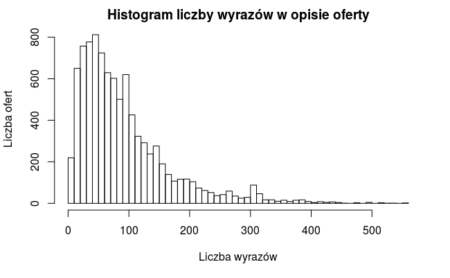

```r
hist(
  pokoje$liczba_wyrazow,
  50,
  main = "Histogram liczby wyrazów w opisie oferty",
  xlab = "Liczba wyrazów",
  ylab = "Liczba ofert"
)
```

Nie trudno było się domyślić, że najczęściej występujące opisy będą krótkie.

Usunę oferty zawierające w cenie informację `Proszę o kontakt` oraz te z `Wymiana/zamiana`. Tak samo postąpię z ofertami, które nie dostarczają informacji o powierzchni wynajmowanej przestrzeni. Dla takich kolumn jak `do_wynajęcia_przez`, `wspoldzielenie` i `liczba_pokoi` w miejsce brakujących wartości wstawię `"Nie podano"`, ponieważ ciężko w tych przpadkach doszukać się jakiegoś domyślnego ustawienia. Natomiast w przypadku `rodzaj_nieruchomosci` brak podanej wartości przypiszę do istniejącej opcji `Inne`. Kolejno `preferowana_plec` posiada wartość `Bez preferencji` i to ona zostanie przypisana w zamian za `NA`. Kierując się zasadą “Co nie jest prawem zabronione, jest dozwolone” założę, że nieokreślone wartości dla kolumn `palacy` oraz `przyjazne_zwierzakom` przyjmują wartości `Tak`. Na koniec `cena` zostaje pozbawiona informacji o walucie i zamieniona na liczbę typu Integer, a klasy odpowiednich zmiennych zostają zamienione na faktory.

```r
pokoje <-
  pokoje %>%
  filter(
    grepl(("Warszawa|Kraków"), lokalizacja),
    !(cena %in% c("Proszę o kontakt", "Wymiana/zamiana")),
    !is.na(wielkosc)
  ) %>%
  mutate(
    do_wynajecia_przez = do_wynajecia_przez %>%
      plyr::mapvalues(NA, "Nie podano") %>%
      as.factor(),
    wspoldzielenie = wspoldzielenie %>%
      plyr::mapvalues(NA, "Nie podano") %>%
      as.factor(),
    liczba_pokoi = liczba_pokoi %>%
      plyr::mapvalues(NA, "Nie podano") %>%
      as.factor(),
    rodzaj_nieruchomosci = rodzaj_nieruchomosci %>%
      plyr::mapvalues(NA, "Inne") %>%
      as.factor(),
    preferowana_plec = preferowana_plec %>%
      plyr::mapvalues(NA, "Bez preferencji") %>%
      as.factor(),
    palacy = palacy %>%
      plyr::mapvalues(NA, "Tak") %>%
      as.factor(),
    przyjazne_zwierzakom = przyjazne_zwierzakom %>%
      plyr::mapvalues(NA, "Tak") %>%
      as.factor(),
    cena = stri_extract_all_charclass(
      cena, "[[:digit:]]"
    ) %>%
      stri_join_list() %>%
      as.integer()
  )
pokoje %>% summary()
```

```
 lokalizacja            opis                cena         do_wynajecia_przez                        wspoldzielenie
 Length:3564        Length:3564        Min.   :   1.0   Agencja   : 188     Nie podano                    : 207
 Class :character   Class :character   1st Qu.: 550.0   Nie podano: 186     Współdzielenie mieszkania/domu:2794
 Mode  :character   Mode  :character   Median : 700.0   Właściciel:3190     Współdzielenie pokoju         : 563
                                       Mean   : 739.4
                                       3rd Qu.: 900.0
                                       Max.   :8000.0

    wielkosc                         liczba_pokoi  rodzaj_nieruchomosci        preferowana_plec palacy
 Min.   :   1.00   2 pokoje                : 929   Dom       : 482      Bez preferencji:2319    Nie:1907
 1st Qu.:  15.00   3 pokoje                :1303   Inne      : 216      Kobieta        : 905    Tak:1657
 Median :  37.50   4 pokoje                : 384   Mieszkanie:2866      Mężczyzna      : 340
 Mean   :  44.52   5 pokoi                 : 141
 3rd Qu.:  60.00   6 lub więcej pokoi      : 198
 Max.   :1200.00   Kawalerka lub garsoniera: 123
                   Nie podano              : 486
 przyjazne_zwierzakom liczba_wyrazow
 Nie:1709             Min.   :  2.0
 Tak:1855             1st Qu.: 45.0
                      Median : 83.0
                      Mean   :106.1
                      3rd Qu.:140.0
                      Max.   :558.0
```

Stosując zasadę ograniczonego zaufania (wiele osób mogło pomylić się podczas wystawiania oferty) przyjrzyjmy się bliżej wartościom przyjmowanym przez cenę oraz wielkość. Po nich spodziewalibyśmy się dość silnej korelacji.

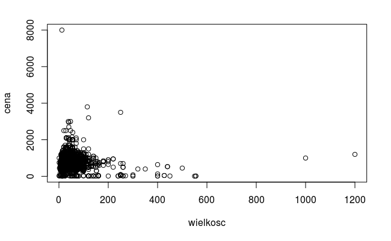

```r
plot(cena~wielkosc, pokoje)
```

Wykres zdecydowanie psują pozycje z ceną powyżej 5000 złotych oraz powierzchnią powyżej 600 metrów kwadratowych. Przyjrzyjmy sie bliżej tym ofertom.

```r
pokoje %>%
  filter(cena == 8000) %>%
  .$opis
```

```
[1] "wynajmę duży pokój z balkonem. Zamykany, umeblowany. W mieszkaniu wszystkie potrzebne sprzęty: lodówka, pralka, kuchenka. Pozostałe pokoje zajęte przez osoby pracujące i studiujące także potrzeba osoby spokojnej i sympatycznej. koszty: osoba pojedyncza 800 + opłaty licznikowe para 1000 + opłaty…
```

Z treści oferty wynika, że cena za jeden pokój dla osoby to 800 pln. Autor oferty dopisał jeden rząd wielkości do ceny. Przypatrzmy się tym od 3000 w górę.

```r
pokoje %>%
  filter(between(cena, 3000, 4000)) %>%
  .$opis
```

```
[1] "DWUPOZIOMOWE MIESZKANIE ODDALONE 3 KM OD CENTRUM KRAKOWA. W POBLIŻU ZNAJDUJĄ SIĘ MIN. PARK AWF, TAURON ARENA KRAKÓW, M1, PLAZA, POLITECHNIKA KRAKOWSKA.DOBRY DOJAZD ZARÓWNO DO CENTRUM KRAKOWA JAK I NOWEJ HUTY."
[2] "Wynajme 2 pokojowe mieszanie na krotki okres (1-3miesiace)Mieszkanie (38m2) znajduje w centrum (Metro Rondo ONZ/Ul.Krochmalna 2). Mieszkanie jest kompletnie wyposażone (pralka, sprzęt kuchenny, lodowka, etc.) \r\nLokalizacja : W centrum, w pobliżu przystanku autobusowy/tramwajowa i metra.\r\nWy…
[3] "Wynajme 2 pokojowe mieszanie na krotki okres (1-3miesiace)Mieszkanie (38m2) znajduje w centrum (Metro Rondo ONZ/Ul.Krochmalna 2). Mieszkanie jest kompletnie wyposażone (pralka, sprzęt kuchenny, lodowka, etc.) \r\nLokalizacja : W centrum, w pobliżu przystanku autobusowy/tramwajowa i metra.\r\nWy…
[4] "Wynajmę dom nieumeblowany przy ul.Kasztanowej na Woli Justowskiej dla grupy studentów lub firmie dla pracowników do czerwca 2017 roku.Blisko do przystanku komunikacji autobusowej - 100 metrów, sklep 150 metrów.Kuchnia jest umeblowana, łazienki też umeblowane-pralka automatyczna też jest.Dom pos…
[5] "Wynajmę pokoje dla osób starszych z opieką medyczną . Cena do uzgodnienia. KONTAKT - LIGKAC@WP.PL"
```

Powyższe przypadki opisują całe mieszkania (lub domy) do wynajęcia. Cena podana jest za mieszkanie/dom (sumę pokojów). W serwisie gumtree.pl istnieje osobny dział do wystawiania takich ofert o nazwie `mieszkania i domy do wynajęcia`. Sprawdźmy co dzieje się przy cenach między 2000 a 3000.

```r
pokoje %>%
  filter(between(cena, 2000, 3000)) %>%
  .$opis
```

```
 [1] "Mam do wynajecia 2 przechodni pokoje do wynajecia w tym samym mieszkaniu w centrum (Metro Ratusz arsenal.Ul Anielewicza 4)  Pokój jest12m który znajduje się w mieszkaniu 3 pokojowym w bloku dzielnica centrum. Mieszkanie jest kompletnie wyposażone (pralka, sprzęt kuchenny, telewizja kablowa, et…
 [2] "Mam do wynajecia duzy pokoj do wynajecia w centrum (Metro Ratusz Arsenal/Ul.Anielewicza 4) Pokój jest 26m który znajduje się w mieszkaniu 2 pokojowym w bloku dzielnica centrum. Mieszkanie jest kompletnie wyposażone (pralka, sprzęt kuchenny, telewizja kablowa, etc.) \r\nLokalizacja : W centrum,…
 [3] "Mieszkanie na Żoliborzu, ul. Dymińska obok Cytadeli.2 pokoje, 1 piętro, blok z cegły.Mieszkanie czyste, ciche, słoneczne, umeblowane, kuchnia widna, osobna, Łazienka z kabiną prysznicową.BARDZO DOBRA LOKALIZACJA! Zielono, dużo miejsc spacerowych.Wymagana jednomiesięczna kaucja.Koszt najmu wyno…
 [4] "Duzy Pokoj dla 1-2osob Od zarazPiekny pokoj do wynajecia W centrum (Metro Ratusz Arsenal/ul.Adersa24) Wynajme pokój 26m2 który znajduje się w 2 pokojowym mieszkaniu. Mieszkanie jest dobrym standardzie kompletnie wyposażone (pralka, zmywarka, sprzęt kuchenny, telewizja kablowa, etc.) Nie toleru…
 [5] "Duzy Pokoj dla 1-2osob Od zarazPiekny pokoj do wynajecia W centrum (Metro Ratusz Arsenal/ul.Adersa24) Wynajme pokój 26m2 który znajduje się w 2 pokojowym mieszkaniu. Mieszkanie jest dobrym standardzie kompletnie wyposażone (pralka, zmywarka, sprzęt kuchenny, telewizja kablowa, etc.) Nie toleru…
 [6] "Dwa nieprzechodnie pokoje z dwoma podwójnymi łóżkami i widokiem na skwer. Oddzielna kuchnia i oddzielna łazienka. Mieszkanie usytułowane na Kazimierzu 10 minut od i Wisły.W pobliżu puby, restauracje i sklep całodobowy.Przystanek tramwajowy i autobusowy za rogiem.Mieszkanie jest w pełni wyposaż…
 [7] "Piekny Duzy Pokoj dla 1-2osob Od zarazPiekny pokoj do wynajecia W centrum (Metro Ratusz Arsenal/ul.Adersa24) Wynajme pokój 26m2 który znajduje się w 2 pokojowym mieszkaniu. Mieszkanie jest dobrym standardzie kompletnie wyposażone (pralka, zmywarka, sprzęt kuchenny, telewizja kablowa, etc.) Nie…
 [8] "Do wynajęcia duży, komfortowy pokój dla 2-3 osób w 3-pokojowym mieszkaniu w kamienicy ( I piętro ). Okolice mostu Dębnickiego.Wspólna łazienka, kuchnia ( z balkonem ) i przedpokój ( w pozostałych pokojach mieszkają 3 osoby).Pokój po remoncie. Nowe wyposażenie (meble): łóżka, biurka, fotele (na…
 [9] "Mam do wynajecia duzy pokoj 26sq.m do wynajecia w centrum (Metro Ratusz Arsenal/Ul.Anielewicza 4) Pokój jest 26m który znajduje się w mieszkaniu 2 pokojowym w bloku dzielnica centrum. Mieszkanie jest kompletnie wyposażone (pralka, sprzęt kuchenny, telewizja kablowa, etc.) \r\nLokalizacja : W c…
[10] "Do wynajęcia dwa mieszkania/kawalerki, znajdujące się obok siebie, na krótko lub dłużej, przytulne i funkcjonalne. W\r\nsamym centrum starego miasta (ul. Zyblikiewicza), w trzypiętrowej zadbanej\r\nkamienicy.Każde posada przestronny pokój dzienny\r\npołączony z sypialnią, aneks kuchenny i łazi…
[11] "Wynajme duzy pokoj na krotki okres (1-3miesiace)Duzy samodzielny pokoj do wynajecia W centrum (Metro Ratusz arsenal/Ul.anielewicza 4) pokój jest 24m który znajduje się w mieszkaniu 2 pokojowym w bloku dzielnica centrum. Mieszkanie jest kompletnie wyposażone (pralka, sprzęt kuchenny, telewizja …
[12] "Wynajme 2 pokojowe mieszanie na krotki okres (1-3miesiace)Mieszkanie (38m2) znajduje w centrum (Metro Rondo ONZ/Ul.Krochmalna 2). Mieszkanie jest kompletnie wyposażone (pralka, sprzęt kuchenny, lodowka, etc.) \r\nLokalizacja : W centrum, w pobliżu przystanku autobusowy/tramwajowa i metra.\r\nW…
[13] "Do wynajęcia od zaraz nowe mieszkanie urządzone w wysokim standardzie na strzeżonym zamkniętym osiedlu fi w krakowie przy ul. Szafrana 5Mieszkanie zlokalizowane jest na 2 piętrze - okna od strony zachodniej - dobrze doświetlone, jasne, przestronnePodłoga - deska lita olejowanaKuchnia - otwarta…
[14] "PolskiWyjątkowy apartament dostępny na długi lub krótki okres od zaraz.2 pokoje niezależne: 18m2 i 12 m2. Mniejszy pokój z balkonem. Z większego pokoju piękny widok na zieleń. Czynsz: 1900 zł + rachunki (internet jest w cenie) lub 2600 zł all inclusiveBudynek położony jest 5 min pieszo do Gale…
[15] "Mam do wynajecia duzy pokoj 26sq.m do wynajecia w centrum (Metro Ratusz Arsenal/Ul.Anielewicza 4) Pokój jest 26m który znajduje się w mieszkaniu 2 pokojowym w bloku dzielnica centrum. Mieszkanie jest kompletnie wyposażone (pralka, sprzęt kuchenny, telewizja kablowa, etc.) \r\nLokalizacja : W c…
```

[output cut: 22 more lines]

Tym razem cena części ofert faktycznie dotyczy jednego pokoju do wynajęcia w dwópokojowym mieszkaniu w pobliżu stacji Metro Ratusz Arsenał. Niestety podany metraż dotyczy całego mieszkania.

Przyjrzyjmy się teraz skrajnym wielkościom.

```r
pokoje %>%
  filter(wielkosc >= 1000) %>%
  .$opis
```

```
[1] "2 Piekni przechodni pokoje do wynajecia W centrum (Metro Ratusz arsenal/Ul.andersa 24) Kazdy pokój ma 14m który znajduje się w mieszkaniu 3 pokojowym w bloku dzielnica centrum. Mieszkanie jest kompletnie wyposażone (pralka, sprzęt kuchenny, telewizja kablowa, etc.) \r\nLokalizacja : W centrum, …
[2] "Wynajme pokoje na krotki okres (1-3miesiace)Piekni pokoje do wynajecia W centrum (Metro Ratusz arsenal/Ul.andersa 24) pokóje sa 14m który znajduje się w mieszkaniu 3 pokojowym w bloku dzielnica centrum. Mieszkanie jest kompletnie wyposażone (pralka, sprzęt kuchenny, zmywarka, telewizja kablowa,…
```

Ciekawe, że dwie najbardziej skrajne oferty pod względem wielkości to kopie najbardziej skranych ofert pod względem ceny. Oczywiście zawierają one błąd i zostaną usunięte. Sprawdźmy co z nieco mniejszymi.

```r
pokoje %>%
  filter(between(wielkosc, 200, 600)) %>%
  .$opis
```

```
 [1] "Hostel z przeznaczeniem dla pracowników i grup zorganizowanych. Bardzo dobre warunki w doskonałej lokalizacji za przyzwoitą cenę.Pokoje 4-, 6- i 8-osobowe.  Także jeden pokój 2-osobowy W każdym pokoju internet WiFi oraz telewizorŁazienki z nowymi prysznicami. Kuchnia w pełni wyposażona (lodówk…
 [2] "Warsawa Targówek ul. Oszmiańska 7 okilce Ronda ŻabaOferujemy pokoje 2, 3, 4 osobowe w hotelu pracowniczym .Pokoje umeblowane , TV , lodówka , internet , czyste i ciepłe . Do dyspozycji kuchnia wyposażona w naczynia i niezbędny sprzęt AGD do gotowania. Dwa węzły sanitarne z WC , umywalkami , na…
 [3] "Noclegi. Pokoje dla Pracowników. Kwatery dla firm.Pokoje 2, 3, 4, 5, 6, 7 osobowe.Obiekt sprzątany codziennie. WiFi, parking za darmo.Ceny  pojedyncza doba - 35 zl.                tydzień - 150 zl.               miesiąc - 550 zl. od osoby.Zapraszamy: 575 537 419"
 [4] "Praca szuka człowieka. 1300zl + pokój na osobnym piętrze. Pierwszy miesiąc próbny 1000zł. Pokój znajduje się na piętrze, gdzie kiedyś był garaż i piwnice, obecnie znajduje się pokój z przeszkloną całą ścianą, wyjściem na małe patio, z którego jest wyjscie na małą uliczkę (osloniete od ulicy), …
 [5] "noclegi 16, 5 Zl\r\nW\r\nnowym, estetycznym, nowoczesnym hostelu oferują łóżka.Pokoje\r\ndla 4 i 6 osób.Zapraszamy\r\ngości miasta, podróżujących w interesach, jak i studentów.\r\nOddzielne pokoje męskie i żeńskie.Miesiąc\r\n= 495 złtydzień\r\n= 149 zł.dzień\r\n= 24, 9 zł.Oferujemy\r\nrównież …
 [6] "Noclegi:miejscowość Łazy, Gmina Jerzmanowice okolice Ojcowa-                                              Do Dyspozycji gości:- 1 pok 2 os. łazienką- 2 pok. 2 os z możliwością dostawki- 2 pok 3 os.z możliwością dostawki+ 2 duże łazienki i 2 osobne WC + aneks kuchenny z naczyniami, kuchenka mik…
 [7] "ZAMYKANY NA KLUCZ, , W OSOBNEJ CZĘŚCI DOMU, UMEBLOWANY W PEŁNI, POZOSTAŁE POKOJE WEJŚCIE Z INNEJ STRONY OD KORYTARZA, OBOK KUCHNIA I ŁAZIENKA, DOJAZD NA pk, DWORZEC LINIĄ 105, AGH 139, UEK 184 SZYBKO W 10 - 15 MINUT, DOBRU W 10 MIN. DOJAZD DO GALERII KRAKOWSKIEJ, 3 PRZYSTANKI, MULTIKUNO, REAL,…
 [8] "W przypadku pytań i rezerwacji prosimy o kontakt telefoniczny: 530 033 423 .OFERTADo dyspozycji gości mamy pokoje 1/2/3/4 osobowe z TV.W hostelu jest darmowe wifi.LOKALIZACJAMieścimy się w budynku zlokalizowanym w willowej części Warszawy. Ulica przy której się znajdujemy jest bardzo cicha, a …
 [9] "Dom jest 13 kilometrów na południowy zachód od Krakowa.Okolice Włosania Gmina Mogilany.Powiat Kraków.Cena za dobę od 8 do 20 złotych za Osobę.Koszt zależy od ilości Osób, długości najmu oraz liczby zajętych pokoi.Możliwość rozliczenia części należności za najem w pracach remontowo-wykończeniow…
[10] "Witam, Zapraszam do wynajęcia jednego z naszych pokoi. Do wynajęcia mamy 1 pokój jednoosobowy. Dostępny od zaraz. Mieszkanie w bardzo atrakcyjnej lokalizacji blisko metra Kabaty. Mieszkanie składa się z 14 nieprzechodnich pokoi, ogólnodostępnej kuchni, 3 niezależnych łazienek. Wysoki standard.…
[11] "Wynajmę pokoje w unikatowym modernistycznym domu wielorodzinnym z 1937 roku na Starych Dębnikach przy ul. Czarodziejskiej.Czynsz za łóżko w pokoju 2/3 osobowym to 400zł + 50 zł ryczałt za media. Pokoje są wyposażone, ogrzewane i zamykane na klucz. Istnieje również możliwość wynajęcia samodziel…
[12] "pokoj w domu jednorodzinnym 15m umeblowany mozliwosc parkowania auta pod domem w pelni umeblowany"
[13] "Zapraszamy do naszych kwater pracowniczych , polozonej blisko skrzyżowania MŁODZIEŃCZA     -RADZYMIŃSKA .\r\nOferujemy pokoje trzy oraz pięcio osobowe.\r\nPokoje są wyposarzone w :\r\n- Łóżka \r\n- Pościel\r\n- Telewizory\r\n- Szafy\r\n- Stoliki\r\nDo wspólnego wykorzystania:\r\n- Kuchnia (lod…
[14] "KAWALERSKIE, WIECZÓR PANIEŃSKI, W LESIE NAD RZEKĄ. IMPREZY DLA GRUPY PRZYJACIÓŁ- POKOJE 2, 3, 4 OSOBOWE- KUCHNIA Z PEŁNYM WYPOSAŻENIEM AGD-SALA Z KOMINKIEM NA DRZEWO- MIEJSCE NA OGNISKO I GRILA-TARASY BIESIADNE-TV SATELITARNA- WI-FI-WYŻYWIENIE, STOŁY BIESIADNE, WYROBY WŁASNE.MOŻLIWY SPŁYW KAJA…
[15] "Zapraszamy do naszych kwater pracowniczych , polozonej blisko przystanku JORSKIEGO (RADZYMIŃSKA)\r\nOddalonej o 10 min od Dworca Wileńskiego.\r\nOferujemy pokoje trzy oraz pięcio osobowe.\r\nPokoje są wyposarzone w :\r\n- Łóżka \r\n- Pościel\r\n- Telewizory\r\n- Szafy\r\n- Stoliki\r\nDo wspóln…
```

[output cut: 25 more lines]

Oferty te dotyczą hoteli pracowniczych lub całych domostw. Tym razem to cena podana jest za pokój, a wielkość opisuje metraż całego mieszaknia/domu. Niestety nie ma żadnej konsekwencji w podawaniu przez oferantów ceny i wielkości powierzchni wynajmu. Raz podany jest metraż całego mieszkania z ceną za pokój i liczbą pokojów. Innym razem podany jest metraż pokoju z ceną za wszystkie pokoje i podaną liczbą pokojów. Żeby ustandaryzować te oferty trzebaby przeprowadzić wyrafinowaną analizę treści opisu, lub wprowadzić poprawki ręcznie, czytając każdą ofertę po kolei. Na potrzeby projektu ograniczę się do usunięcia tak skrajnych przypadków, aż nie uzyskam w miarę rozsądnej korelacji między tymi dwoma wartościami.

Przyjrzyjmy sie jeszcze ofertom posiadającym wyjątkowo niską cenę (poniżej 100 PLN) i bardzo mały metraż (10 m^2).

```r
pokoje %>%
  filter(
    cena <= 100,
    wielkosc <= 10
  ) %>%
  .$opis
```

```
[1] "DO DYSPOZYCJI GOŚCI ODDAJEMY 36 miejsc noclegowych na dwóch kondygnacjachPosiadamy 6 pokoi 6-osobowych. Oferta skierowana do grup.Pokoje są ogrzewane c.o. i wyposażone w:-łóżka (piętrowe i pojedyncze)-szafę ubraniową-szafki nocne-stół-krzesła-lampkę nocną-gniazdko internetowePonadto na każdym p…
[2] "HOSTEL tanie noclegi pokoje kwatery do wynajęcia WARSZAWA Wilanów Mokotów\r\n\r\n\r\nPokoje Gościnne w Klimatycznej Willi z lat 70tych na Sadybie-Mokotów\r\nZdrojowa 28 Hostel.\r\n\r\n\r\nwww.Zdrojowa28Hostel.pl\r\n\r\n\r\nInformacje poprzez kontakt telefoniczny 9:00-20:00\r\nlub mailowy \r\nZa…
[3] "Do okoła pełno kawiarni i restauracji. Po przejściu mostu jesteśmy w Centrum. Niezwykle cicha okolica z dala od zgiełku miasta."
[4] "Oferujemy komfortowe pokoje w przystępnej cenie na Bemowie w Warszawie.\r\nPokoje 2, 3-4 osobowe z tv, internetem i czystą pościelą. Kuchnia w pełni wyposażona, 3 łazienki z prysznicem. Bezpieczne miejsca parkingowe.\r\nDoskonała lokalizacja- Warszawa Bemowo blisko Ul.Powstańców Śląskich, Górcz…
[5] "Jesteś przejazdem w Katowicach i szukasz noclegu blisko centrum? Oferujemy wygodne pokoje w przystępnej cenie. Mieścimy się tylko kilkaset metrów od Spodka w spokojnej dzielnicy - Koszutka. U nas w cenie pokoju pooglądasz kablówkę i skorzystasz z bezpłatnego wifi. Mamy 7 pokoi 2-3 i 4 osobowych…
[6] "Oferujemy komfortowe pokoje w przystępnej cenie na Bemowie w Warszawie.\r\nPokoje 2, 3-4 osobowe z tv, internetem i czystą pościelą. Kuchnia w pełni wyposażona, 3 łazienki z prysznicem. Bezpieczne miejsca parkingowe.\r\nDoskonała lokalizacja- Warszawa Bemowo blisko Ul.Powstańców Śląskich, Górcz…
[7] "DO DYSPOZYCJI GOŚCI ODDAJEMY 36 miejsc noclegowych na dwóch kondygnacjachPosiadamy 6 pokoi 6-osobowych. Oferta skierowana do grup.Pokoje są ogrzewane c.o. i wyposażone w:-łóżka (piętrowe i pojedyncze)-szafę ubraniową-szafki nocne-stół-krzesła-lampkę nocną-gniazdko internetowePonadto na każdym p…
```

W tych ofertach zdecydowanie nieprawidłowo podano wielkość. 6 osobowy pokój raczej nie ma 5 m^2, zaś 3-4 osobowy nie ma 1 m^2.

Co się stanie, gdy ograniczę zestaw danych ze względu na cenę i wielkość przyjmując nieco węższe - eliminujące wadliwe oferty - widełki?

```r
test01 <-
  pokoje %>%
  select(-opis) %>%
  filter(
    between(cena, 100, 1000),
    between(wielkosc, 10, 30)
  )
summary(test01)
```

```
 lokalizacja             cena         do_wynajecia_przez                        wspoldzielenie    wielkosc
 Length:1397        Min.   : 100.0   Agencja   : 114     Nie podano                    :  98   Min.   :10.00
 Class :character   1st Qu.: 550.0   Nie podano: 120     Współdzielenie mieszkania/domu:1084   1st Qu.:12.00
 Mode  :character   Median : 700.0   Właściciel:1163     Współdzielenie pokoju         : 215   Median :15.00
                    Mean   : 679.7                                                             Mean   :15.73
                    3rd Qu.: 800.0                                                             3rd Qu.:20.00
                    Max.   :1000.0                                                             Max.   :30.00

                   liczba_pokoi rodzaj_nieruchomosci        preferowana_plec palacy    przyjazne_zwierzakom
 2 pokoje                :329   Dom       :331       Bez preferencji:908     Nie:680   Nie:631
 3 pokoje                :420   Inne      :147       Kobieta        :299     Tak:717   Tak:766
 4 pokoje                :117   Mieszkanie:919       Mężczyzna      :190
 5 pokoi                 : 53
 6 lub więcej pokoi      : 41
 Kawalerka lub garsoniera: 68
 Nie podano              :369
 liczba_wyrazow
 Min.   :  2.00
 1st Qu.: 37.00
 Median : 70.00
 Mean   : 86.99
 3rd Qu.:115.00
 Max.   :558.00
```

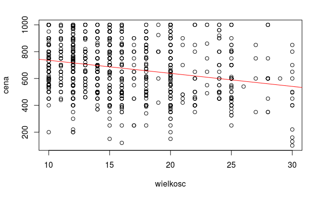

```r
plot(cena~wielkosc, test01)
fit01 <- lm(cena~wielkosc, test01)
abline(fit01, col = "red")
```

Nieintuicyjnie cena pokojów do wynajęcia spada wraz ze wzrostem metrażu. Może być to spowodowane dalszą niekonsekwencją we wprowadzaniu danych przez oferantów. Na tym etapie postanowiłem przyjrzeć się innym danym z portalu gumtree.pl. Tym razem oferty dotyczą mieszkań i domów do wynajęcia. Ponieważ ofert jest w sumie niemalże 30 tysięcy postanowiłem ograniczyć się do Warszawy (13 tysięcy ofert) już na etapie scrapowania danych.

Dla mieszkań i domów zmieniły się dwa atrybuty do nadania ofertom. Zniknęły kolumny `wspoldzielenie` i `preferowana_pleć` zaś pojawiły się `parking` oraz `liczba_lazienek`. Tym razem ciężko o pomyłkę przy wpisywaniu ceny - mieszaknie jest traktowane jako całość i niezależnie od ilości pokojów cena powinna być podana za całość. To samo tyczy się metrażu. Sprawdźmy więc, czy aby napewno tak jest. Najpierw jednak uporządkujmy dane.

```r
mieszkania <- read_csv("2016-11-23_Warszawa_df.csv")
mieszkania %>% names()
```

```
 [1] "data_dodania"         "lokalizacja"          "href"                 "opis"
 [5] "adres"                "cena"                 "tytuł"                "do_wynajęcia_przez"
 [9] "liczba_pokoi"         "rodzaj_nieruchomości" "wielkość_(m2)"        "parking"
[13] "liczba_łazienek"      "dostępny"             "palący"               "przyjazne_zwierzakom"
```

```r
names(mieszkania) <-
  names(mieszkania) %>% chartr("ąęółćśźż", "aeolcszz", .)
mieszkania <-
  mieszkania %>%
  rename(wielkosc  = `wielkosc_(m2)`) %>%
  select(-c(data_dodania, href, adres, tytul, dostepny)) %>%
  mutate(
    liczba_wyrazow = stri_count_words(opis)
  )
mieszkania %>%
  select(-opis) %>%
  lapply(
    function(x) {
      x %>%
        table(useNA = "always") %>%
        sort(decreasing = TRUE) %>%
        head(20)
    }
  )
```

```
$lokalizacja
.
       Mokotów, Warszawa    Śródmieście, Warszawa           Wola, Warszawa Praga Południe, Warszawa
                    3756                     3217                     1184                      945
       Wilanów, Warszawa        Ursynów, Warszawa         Ochota, Warszawa        Bielany, Warszawa
                     900                      717                      686                      553
        Bemowo, Warszawa       Żoliborz, Warszawa          Wawer, Warszawa   Praga Północ, Warszawa
                     458                      457                      209                      178
     Białołęka, Warszawa       Targówek, Warszawa         Włochy, Warszawa          Ursus, Warszawa
                     169                      152                      143                       84
        Wesoła, Warszawa      Rembertów, Warszawa                     <NA>
                      26                       15                        0

$cena
.
        2 500 zł         3 000 zł         3 500 zł         2 400 zł         2 600 zł         2 300 zł
             906              550              535              510              466              457
        2 800 zł         2 200 zł         2 100 zł         4 500 zł         4 000 zł Proszę o kontakt
             405              397              387              365              350              350
        2 000 zł         2 700 zł         3 200 zł         2 900 zł         6 000 zł         5 500 zł
             337              337              326              283              233              223
        6 500 zł         5 000 zł
             223              215

$do_wynajecia_przez
.
   Agencja Właściciel       <NA>
     11458       2266        125

$liczba_pokoi
.
                2 pokoje                 3 pokoje                 4 pokoje Kawalerka lub garsoniera
                    6945                     3419                     1066                      999
      6 lub więcej pokoi                  5 pokoi                     <NA>
                     813                      478                      129

$rodzaj_nieruchomosci
.
Mieszkanie        Dom       <NA>       Inne
     12581       1122        115         31
```

[output cut: 15 more lines]

```

$palacy
.
 <NA>   Nie   Tak
12194  1410   245

$przyjazne_zwierzakom
.
 <NA>   Nie   Tak
11597  1427   825

$liczba_wyrazow
.
160 154  67 162 136 156 161 150  96 184 155 135  95 152 158 164  74 104 147 148
138 130 122 122 110 110 109 108 107 106 103 102 101 101 101 101 100 100 100  99
```

```r
mieszkania <-
  mieszkania %>%
  filter(
    !(cena %in% c("Proszę o kontakt", "Wymiana/zamiana")),
    !is.na(wielkosc)
  ) %>%
  mutate(
    do_wynajecia_przez = do_wynajecia_przez %>%
      plyr::mapvalues(NA, "Nie podano") %>%
      as.factor(),
    parking = parking %>%
      plyr::mapvalues(NA, "Nie podano") %>%
      as.factor(),
    liczba_pokoi = liczba_pokoi %>%
      plyr::mapvalues(NA, "Nie podano") %>%
      as.factor(),
    rodzaj_nieruchomosci = rodzaj_nieruchomosci %>%
      plyr::mapvalues(NA, "Inne") %>%
      as.factor(),
    liczba_lazienek = liczba_lazienek %>%
      plyr::mapvalues(NA, "Nie podano") %>%
      as.factor(),
    palacy = palacy %>%
      plyr::mapvalues(NA, "Tak") %>%
      as.factor(),
    przyjazne_zwierzakom = przyjazne_zwierzakom %>%
      plyr::mapvalues(NA, "Tak") %>%
      as.factor(),
    cena = stri_extract_all_charclass(
      cena, "[[:digit:]]"
    ) %>%
      stri_join_list() %>%
      as.integer()
  )
mieszkania %>% summary()
```

```
 lokalizacja            opis                cena          do_wynajecia_przez                   liczba_pokoi
 Length:13390       Length:13390       Min.   :     20   Agencja   :11303    2 pokoje                :6745
 Class :character   Class :character   1st Qu.:   2400   Nie podano:   83    3 pokoje                :3345
 Mode  :character   Mode  :character   Median :   3000   Właściciel: 2004    4 pokoje                :1040
                                       Mean   :   4685                       5 pokoi                 : 467
                                       3rd Qu.:   4500                       6 lub więcej pokoi      : 798
                                       Max.   :2133000                       Kawalerka lub garsoniera: 927
                                                                             Nie podano              :  68
 rodzaj_nieruchomosci    wielkosc             parking                  liczba_lazienek palacy
 Dom       : 1086     Min.   :   1.00   Brak      : 107   1 łazienka           :6289   Nie: 1287
 Inne      :   97     1st Qu.:  46.00   Garaż     :3430   2 łazienki           : 988   Tak:12103
 Mieszkanie:12207     Median :  58.00   Kryty     :1365   3 łazienki           : 143
                      Mean   :  87.65   Nie podano:6634   4 lub więcej łazienek:  57
                      3rd Qu.:  88.00   Ulica     :1854   Nie podano           :5913
                      Max.   :6000.00

 przyjazne_zwierzakom liczba_wyrazow
 Nie: 1334            Min.   :  2.0
 Tak:12056            1st Qu.: 89.0
                      Median :133.0
                      Mean   :140.5
                      3rd Qu.:171.0
                      Max.   :611.0
```

Ponownie skrajne wartości ceny i wielkości są podejrzane. Przypatrzmy się im bliżej.

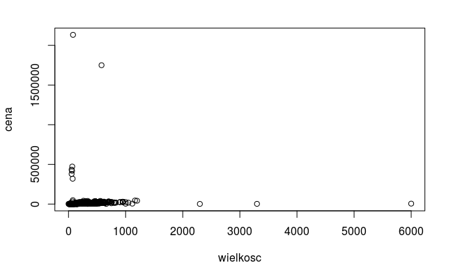

```r
plot(cena~wielkosc, mieszkania)
```

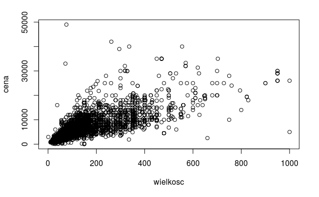

```r
test11 <-
  mieszkania %>%
  filter(
    cena <= 100000,
    wielkosc <= 1000
  )
plot(cena~wielkosc, test11)
```

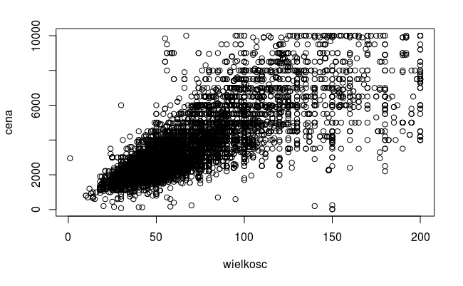

```r
test12 <-
  mieszkania %>%
  filter(
    cena <= 10000,
    wielkosc <= 200
  )
plot(cena~wielkosc, test12)
```

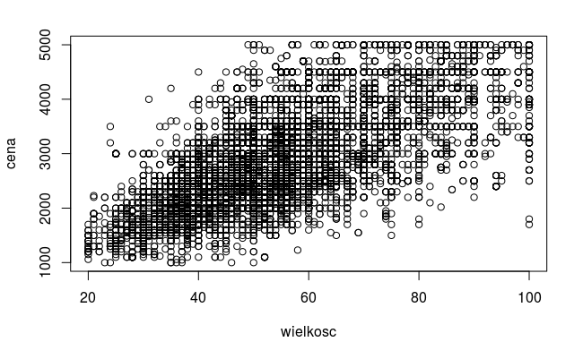

```r
test13 <-
  mieszkania %>%
  filter(
    between(cena, 1000, 5000),
    between(wielkosc, 20, 100)
  )
plot(cena~wielkosc, test13)
```

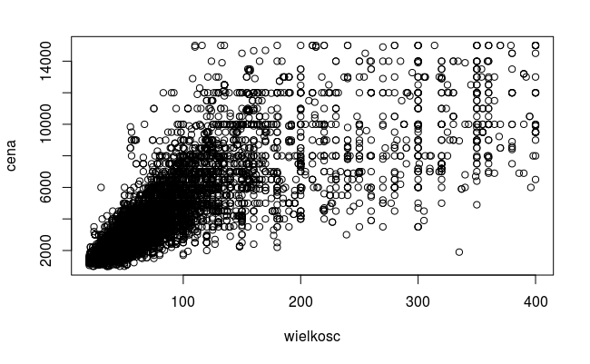

```r
test14 <-
  mieszkania %>%
  filter(
    between(cena, 1000, 15000),
    between(wielkosc, 20, 400)
  )
plot(cena~wielkosc, test14)
```

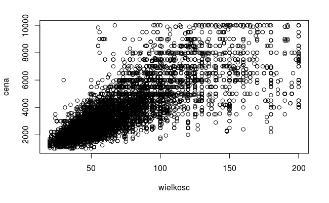

```r
test15 <-
  mieszkania %>%
  filter(
    between(cena, 1000, 10000),
    between(wielkosc, 20, 200)
  )
plot(cena~wielkosc, test15)
```

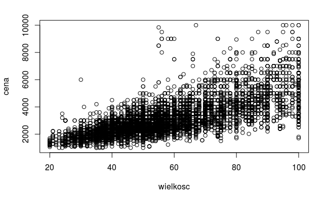

```r
test16 <-
  mieszkania %>%
  filter(
    between(cena, 1000, 10000),
    between(wielkosc, 20, 100)
  )
plot(cena~wielkosc, test16)
```

```r
dane <-
  test13 %>%
  select(-opis)
summary(dane)
```

```
 lokalizacja             cena       do_wynajecia_przez                   liczba_pokoi  rodzaj_nieruchomosci
 Length:10005       Min.   :1000   Agencja   :8062     2 pokoje                :6590   Dom       :  47
 Class :character   1st Qu.:2300   Nie podano:  69     3 pokoje                :2280   Inne      :  76
 Mode  :character   Median :2650   Właściciel:1874     4 pokoje                : 220   Mieszkanie:9882
                    Mean   :2843                       5 pokoi                 :   5
                    3rd Qu.:3300                       6 lub więcej pokoi      :   1
                    Max.   :5000                       Kawalerka lub garsoniera: 884
                                                       Nie podano              :  25
    wielkosc            parking                  liczba_lazienek palacy     przyjazne_zwierzakom liczba_wyrazow
 Min.   : 20.00   Brak      :  93   1 łazienka           :5902   Nie:1193   Nie:1241             Min.   :  2.0
 1st Qu.: 43.00   Garaż     :2758   2 łazienki           : 451   Tak:8812   Tak:8764             1st Qu.: 85.0
 Median : 52.00   Kryty     : 574   3 łazienki           :   1                                   Median :129.0
 Mean   : 54.15   Nie podano:5024   4 lub więcej łazienek:   1                                   Mean   :134.4
 3rd Qu.: 62.00   Ulica     :1556   Nie podano           :3650                                   3rd Qu.:167.0
 Max.   :100.00                                                                                  Max.   :528.0
```

# Regresja liniowa

## Funkcja liniowa

```r
plot(cena~wielkosc, dane)
fit11 <- lm(cena~wielkosc, dane)
summary(fit11)
```

```
Call:
lm(formula = cena ~ wielkosc, data = dane)

Residuals:
     Min       1Q   Median       3Q      Max
-2751.84  -397.47   -71.16   353.40  2337.61

Coefficients:
            Estimate Std. Error t value Pr(>|t|)
(Intercept) 943.1021    21.2184   44.45   <2e-16 ***
wielkosc     35.0874     0.3761   93.28   <2e-16 ***
---
Signif. codes:  0 ‘***’ 0.001 ‘**’ 0.01 ‘*’ 0.05 ‘.’ 0.1 ‘ ’ 1

Residual standard error: 595.1 on 10003 degrees of freedom
Multiple R-squared:  0.4652,    Adjusted R-squared:  0.4652
F-statistic:  8702 on 1 and 10003 DF,  p-value: < 2.2e-16
```

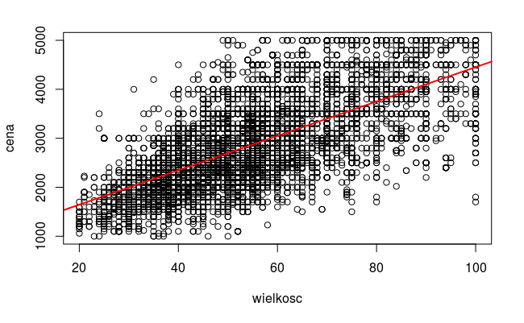

```r
abline(fit11, col = "red", lwd = 2)
```

Zobaczmy jak cena zależy od pozostałych predykatów.

```r
fit12 <-
  lm(cena~., dane)
summary(fit12)
```

```
Call:
lm(formula = cena ~ ., data = dane)

Residuals:
     Min       1Q   Median       3Q      Max
-2396.82  -306.71   -41.21   265.44  2360.59

Coefficients:
                                       Estimate Std. Error t value Pr(>|t|)
(Intercept)                           704.07025  100.83986   6.982 3.09e-12 ***
lokalizacjaBiałołęka, Warszawa       -237.87954   49.06485  -4.848 1.26e-06 ***
lokalizacjaBielany, Warszawa          193.75822   33.80390   5.732 1.02e-08 ***
lokalizacjaMokotów, Warszawa          626.75092   26.80746  23.380  < 2e-16 ***
lokalizacjaOchota, Warszawa           515.49644   32.69096  15.769  < 2e-16 ***
lokalizacjaPraga Północ, Warszawa     421.57712   48.98762   8.606  < 2e-16 ***
lokalizacjaPraga Południe, Warszawa   244.85947   30.79142   7.952 2.03e-15 ***
lokalizacjaRembertów, Warszawa       -103.54603  175.54770  -0.590 0.555308
lokalizacjaŚródmieście, Warszawa      808.88225   27.17290  29.768  < 2e-16 ***
lokalizacjaTargówek, Warszawa         -71.46235   51.15987  -1.397 0.162492
lokalizacjaUrsus, Warszawa           -127.28971   70.98582  -1.793 0.072976 .
lokalizacjaUrsynów, Warszawa          212.77260   32.69910   6.507 8.04e-11 ***
lokalizacjaWawer, Warszawa           -259.87870   68.24197  -3.808 0.000141 ***
lokalizacjaWesoła, Warszawa          -749.57663  175.97769  -4.259 2.07e-05 ***
lokalizacjaWilanów, Warszawa          463.15588   34.79566  13.311  < 2e-16 ***
lokalizacjaWłochy, Warszawa           192.77545   59.20619   3.256 0.001134 **
lokalizacjaWola, Warszawa             564.26670   29.31494  19.248  < 2e-16 ***
lokalizacjaŻoliborz, Warszawa         529.07429   36.26477  14.589  < 2e-16 ***
do_wynajecia_przezNie podano          -39.40269   59.75994  -0.659 0.509687
do_wynajecia_przezWłaściciel         -193.03556   15.51514 -12.442  < 2e-16 ***
liczba_pokoi3 pokoje                  189.35420   15.84874  11.948  < 2e-16 ***
liczba_pokoi4 pokoje                  243.86488   37.67650   6.473 1.01e-10 ***
liczba_pokoi5 pokoi                   192.41558  220.86949   0.871 0.383681
liczba_pokoi6 lub więcej pokoi         75.86677  493.20126   0.154 0.877751
liczba_pokoiKawalerka lub garsoniera -185.85131   19.56732  -9.498  < 2e-16 ***
liczba_pokoiNie podano                  7.33078   99.39017   0.074 0.941205
rodzaj_nieruchomosciInne             -307.34257   94.54000  -3.251 0.001154 **
rodzaj_nieruchomosciMieszkanie       -130.39173   76.08872  -1.714 0.086619 .
wielkosc                               27.49387    0.49561  55.475  < 2e-16 ***
parkingGaraż                          250.91295   52.43018   4.786 1.73e-06 ***
parkingKryty                           49.78108   55.62628   0.895 0.370851
parkingNie podano                     -22.05660   51.94819  -0.425 0.671146
parkingUlica                          -68.65787   52.56456  -1.306 0.191527
liczba_lazienek2 łazienki              54.60075   25.91378   2.107 0.035141 *
liczba_lazienek3 łazienki            -416.93398  491.30932  -0.849 0.396114
liczba_lazienek4 lub więcej łazienek -599.71339  491.39611  -1.220 0.222332
liczba_lazienekNie podano             208.91558   12.23168  17.080  < 2e-16 ***
palacyTak                              18.58975   20.93136   0.888 0.374493
przyjazne_zwierzakomTak                -6.66947   18.91470  -0.353 0.724390
liczba_wyrazow                          1.00732    0.07335  13.732  < 2e-16 ***
---
Signif. codes:  0 ‘***’ 0.001 ‘**’ 0.01 ‘*’ 0.05 ‘.’ 0.1 ‘ ’ 1

Residual standard error: 490.8 on 9965 degrees of freedom
Multiple R-squared:  0.6377,    Adjusted R-squared:  0.6363
F-statistic: 449.8 on 39 and 9965 DF,  p-value: < 2.2e-16
```

```
not plotting observations with leverage one:
  4141
```

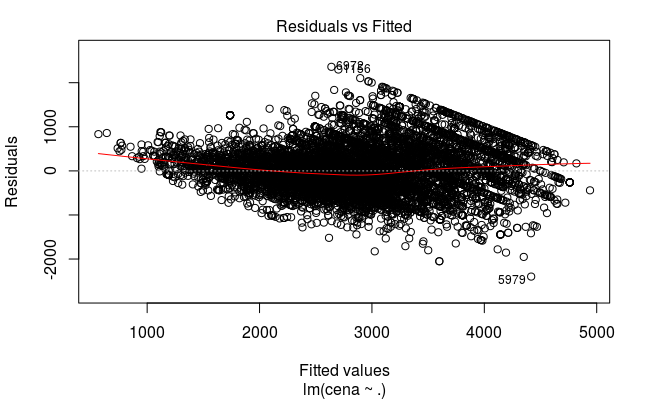

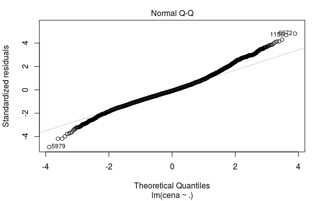

```
not plotting observations with leverage one:
  4141
```

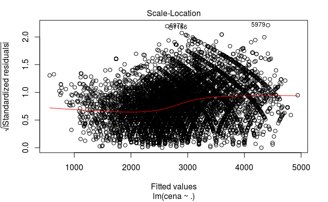

```
NaNs producedNaNs produced
```

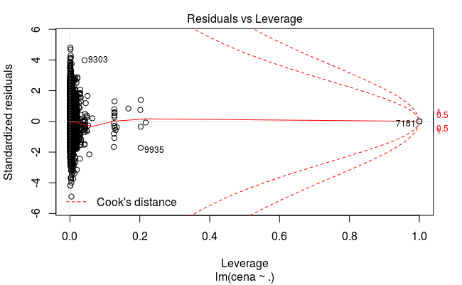

```r
plot(fit12)
```

Okazuje się, że predykaty `palacy` oraz `przyjazne_zwierzakom` nie są istotne w zbudowanym modelu. Dla uproszczenia go usuniemy te dwie kolumny. Pozostałe nieistotne parametry należą do grup czynników, z których część jest istotna, dlatego nie zostaną usunięte (należałoby wtedy usunąć też te istotne). Można zaobserwować, że stworzona nowa zmienna dotycząca liczby słów w ofercie jest bardzo istotnym predykatem w naszym modelu.

```r
fit13 <-
  lm(cena~.-palacy-przyjazne_zwierzakom, dane)
summary(fit13)
```

```
Call:
lm(formula = cena ~ . - palacy - przyjazne_zwierzakom, data = dane)

Residuals:
     Min       1Q   Median       3Q      Max
-2396.22  -304.85   -40.15   265.41  2365.51

Coefficients:
                                      Estimate Std. Error t value Pr(>|t|)
(Intercept)                           712.1602    99.5419   7.154 9.00e-13 ***
lokalizacjaBiałołęka, Warszawa       -237.9705    49.0467  -4.852 1.24e-06 ***
lokalizacjaBielany, Warszawa          194.5367    33.7906   5.757 8.81e-09 ***
lokalizacjaMokotów, Warszawa          627.6341    26.7809  23.436  < 2e-16 ***
lokalizacjaOchota, Warszawa           515.9436    32.6830  15.786  < 2e-16 ***
lokalizacjaPraga Północ, Warszawa     420.8601    48.9708   8.594  < 2e-16 ***
lokalizacjaPraga Południe, Warszawa   245.4484    30.7825   7.974 1.71e-15 ***
lokalizacjaRembertów, Warszawa       -102.8265   175.5255  -0.586 0.558009
lokalizacjaŚródmieście, Warszawa      809.8175    27.1509  29.827  < 2e-16 ***
lokalizacjaTargówek, Warszawa         -71.7125    51.1552  -1.402 0.160988
lokalizacjaUrsus, Warszawa           -128.1804    70.8767  -1.808 0.070559 .
lokalizacjaUrsynów, Warszawa          213.7893    32.6772   6.542 6.35e-11 ***
lokalizacjaWawer, Warszawa           -261.5256    68.1980  -3.835 0.000126 ***
lokalizacjaWesoła, Warszawa          -748.0420   175.9409  -4.252 2.14e-05 ***
lokalizacjaWilanów, Warszawa          464.4916    34.7410  13.370  < 2e-16 ***
lokalizacjaWłochy, Warszawa           195.0741    59.0832   3.302 0.000964 ***
lokalizacjaWola, Warszawa             564.9185    29.3026  19.279  < 2e-16 ***
lokalizacjaŻoliborz, Warszawa         529.1616    36.2569  14.595  < 2e-16 ***
do_wynajecia_przezNie podano          -40.6126    59.7340  -0.680 0.496589
do_wynajecia_przezWłaściciel         -198.0321    14.1090 -14.036  < 2e-16 ***
liczba_pokoi3 pokoje                  189.9214    15.8236  12.002  < 2e-16 ***
liczba_pokoi4 pokoje                  244.6579    37.6529   6.498 8.54e-11 ***
liczba_pokoi5 pokoi                   193.0140   220.8508   0.874 0.382163
liczba_pokoi6 lub więcej pokoi         80.8178   493.1401   0.164 0.869826
liczba_pokoiKawalerka lub garsoniera -187.1034    19.5130  -9.589  < 2e-16 ***
liczba_pokoiNie podano                  7.7294    99.3604   0.078 0.937995
rodzaj_nieruchomosciInne             -304.8877    94.4584  -3.228 0.001252 **
rodzaj_nieruchomosciMieszkanie       -129.6030    76.0278  -1.705 0.088285 .
wielkosc                               27.4854     0.4944  55.592  < 2e-16 ***
parkingGaraż                          253.6139    52.3288   4.847 1.28e-06 ***
parkingKryty                           51.9306    55.5460   0.935 0.349857
parkingNie podano                     -18.9926    51.7772  -0.367 0.713766
parkingUlica                          -67.5128    52.5394  -1.285 0.198824
liczba_lazienek2 łazienki              54.0467    25.9047   2.086 0.036970 *
liczba_lazienek3 łazienki            -417.1775   491.2795  -0.849 0.395810
liczba_lazienek4 lub więcej łazienek -599.8718   491.3659  -1.221 0.222181
liczba_lazienekNie podano             209.6856    12.1026  17.326  < 2e-16 ***
liczba_wyrazow                          1.0032     0.0732  13.706  < 2e-16 ***
---
Signif. codes:  0 ‘***’ 0.001 ‘**’ 0.01 ‘*’ 0.05 ‘.’ 0.1 ‘ ’ 1

Residual standard error: 490.7 on 9967 degrees of freedom
Multiple R-squared:  0.6377,    Adjusted R-squared:  0.6364
F-statistic: 474.2 on 37 and 9967 DF,  p-value: < 2.2e-16
```

```
not plotting observations with leverage one:
  4141
```

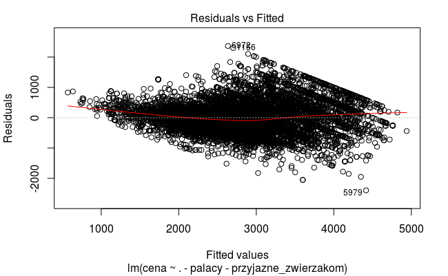

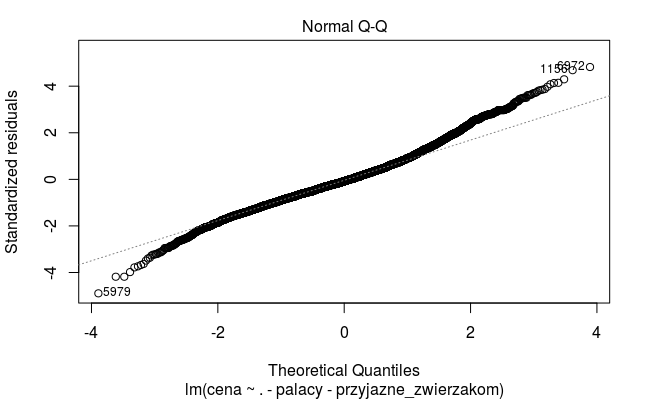

```
not plotting observations with leverage one:
  4141
```

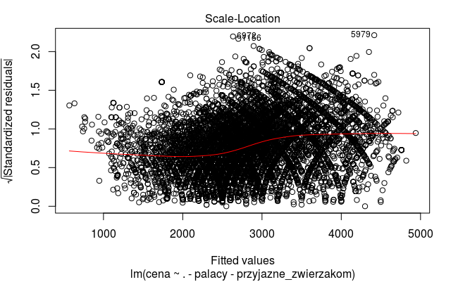

```
NaNs producedNaNs produced
```

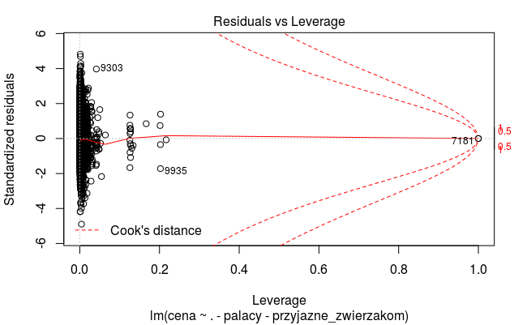

```r
plot(fit13)
```

Spróbujmy wykorzystać interakcję miedzy dwoma predykatami - `lokalizacja` i `wielkosc`.

```r
fit14 <-
  lm(cena~.+lokalizacja*wielkosc, dane)
summary(fit14)
```

```
Call:
lm(formula = cena ~ . + lokalizacja * wielkosc, data = dane)

Residuals:
     Min       1Q   Median       3Q      Max
-2489.73  -298.90   -39.64   255.47  2367.05

Coefficients:
                                               Estimate Std. Error t value Pr(>|t|)
(Intercept)                                  1374.55688  144.83668   9.490  < 2e-16 ***
lokalizacjaBiałołęka, Warszawa                -82.90232  183.05073  -0.453 0.650636
lokalizacjaBielany, Warszawa                  120.91408  131.16435   0.922 0.356628
lokalizacjaMokotów, Warszawa                 -184.33139  114.84130  -1.605 0.108504
lokalizacjaOchota, Warszawa                   181.10415  127.48266   1.421 0.155459
lokalizacjaPraga Północ, Warszawa            -399.76798  177.64268  -2.250 0.024445 *
lokalizacjaPraga Południe, Warszawa          -269.50796  128.70292  -2.094 0.036282 *
lokalizacjaRembertów, Warszawa                109.74751  684.51929   0.160 0.872626
lokalizacjaŚródmieście, Warszawa               27.14971  114.14499   0.238 0.812000
lokalizacjaTargówek, Warszawa                  53.77617  181.58811   0.296 0.767127
lokalizacjaUrsus, Warszawa                   -137.76178  270.28044  -0.510 0.610273
lokalizacjaUrsynów, Warszawa                 -399.80201  140.00798  -2.856 0.004305 **
lokalizacjaWawer, Warszawa                    -18.36094  216.11121  -0.085 0.932294
lokalizacjaWesoła, Warszawa                  -510.13982  596.12977  -0.856 0.392155
lokalizacjaWilanów, Warszawa                 -283.97696  138.16816  -2.055 0.039876 *
lokalizacjaWłochy, Warszawa                   166.42562  194.93889   0.854 0.393274
lokalizacjaWola, Warszawa                     211.05453  125.35235   1.684 0.092273 .
lokalizacjaŻoliborz, Warszawa                -402.16764  138.89507  -2.895 0.003794 **
do_wynajecia_przezNie podano                  -49.92389   58.95881  -0.847 0.397150
do_wynajecia_przezWłaściciel                 -192.58799   15.35378 -12.543  < 2e-16 ***
liczba_pokoi3 pokoje                          190.24173   15.73718  12.089  < 2e-16 ***
liczba_pokoi4 pokoje                          329.77387   38.14501   8.645  < 2e-16 ***
liczba_pokoi5 pokoi                           134.36978  218.18204   0.616 0.538000
liczba_pokoi6 lub więcej pokoi               -211.17161  490.57201  -0.430 0.666870
liczba_pokoiKawalerka lub garsoniera         -203.51629   19.41928 -10.480  < 2e-16 ***
liczba_pokoiNie podano                        -40.61121   98.35203  -0.413 0.679676
rodzaj_nieruchomosciInne                     -366.41945   94.60006  -3.873 0.000108 ***
rodzaj_nieruchomosciMieszkanie               -191.08330   76.83905  -2.487 0.012906 *
wielkosc                                       16.76707    1.89570   8.845  < 2e-16 ***
parkingGaraż                                  253.57132   51.74185   4.901 9.70e-07 ***
parkingKryty                                   52.72666   54.88575   0.961 0.336745
```

[output cut: 17 more lines]

```
lokalizacjaTargówek, Warszawa:wielkosc         -3.52585    3.23411  -1.090 0.275648
lokalizacjaUrsus, Warszawa:wielkosc            -0.12333    4.63532  -0.027 0.978775
lokalizacjaUrsynów, Warszawa:wielkosc          10.59094    2.32855   4.548 5.47e-06 ***
lokalizacjaWawer, Warszawa:wielkosc            -4.34830    3.54298  -1.227 0.219739
lokalizacjaWesoła, Warszawa:wielkosc           -2.11969    8.53084  -0.248 0.803773
lokalizacjaWilanów, Warszawa:wielkosc          12.83874    2.28903   5.609 2.09e-08 ***
lokalizacjaWłochy, Warszawa:wielkosc            0.84539    3.09373   0.273 0.784659
lokalizacjaWola, Warszawa:wielkosc              5.51794    2.18498   2.525 0.011572 *
lokalizacjaŻoliborz, Warszawa:wielkosc         16.57596    2.38374   6.954 3.78e-12 ***
---
Signif. codes:  0 ‘***’ 0.001 ‘**’ 0.01 ‘*’ 0.05 ‘.’ 0.1 ‘ ’ 1

Residual standard error: 483.6 on 9948 degrees of freedom
Multiple R-squared:  0.6488,    Adjusted R-squared:  0.6468
F-statistic: 328.2 on 56 and 9948 DF,  p-value: < 2.2e-16
```

```
not plotting observations with leverage one:
  4141
```

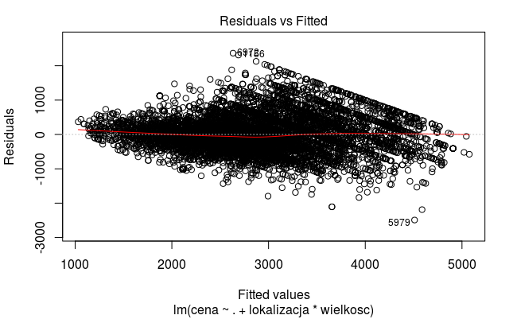

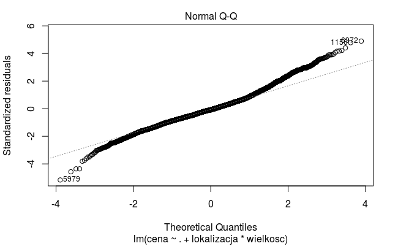

```
not plotting observations with leverage one:
  4141
```

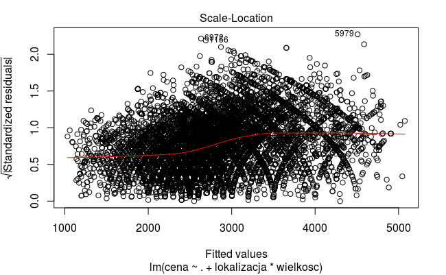

```
NaNs producedNaNs produced
```

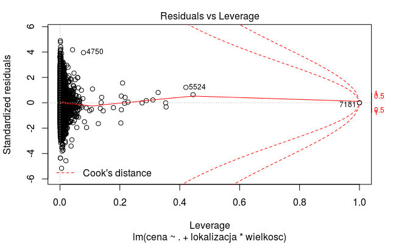

```r
plot(fit14)
```

## Wielomiany

Spróbujmy teraz dopasować model nieliniowy. Najpierw od samej wielkości mieszkania.

```r
plot(cena~wielkosc, dane)
fit21 <-
  lm(cena~wielkosc+I(wielkosc^2), dane)
summary(fit21)
```

```
Call:
lm(formula = cena ~ wielkosc + I(wielkosc^2), data = dane)

Residuals:
     Min       1Q   Median       3Q      Max
-2564.89  -391.64   -62.57   357.77  2314.42

Coefficients:
               Estimate Std. Error t value Pr(>|t|)
(Intercept)   482.79763   62.61387   7.711 1.37e-14 ***
wielkosc       51.80885    2.17341  23.838  < 2e-16 ***
I(wielkosc^2)  -0.13988    0.01791  -7.811 6.25e-15 ***
---
Signif. codes:  0 ‘***’ 0.001 ‘**’ 0.01 ‘*’ 0.05 ‘.’ 0.1 ‘ ’ 1

Residual standard error: 593.4 on 10002 degrees of freedom
Multiple R-squared:  0.4685,    Adjusted R-squared:  0.4684
F-statistic:  4408 on 2 and 10002 DF,  p-value: < 2.2e-16
```

```r
points(dane$wielkosc, fitted(fit21), col = "blue", pch = 20)
```

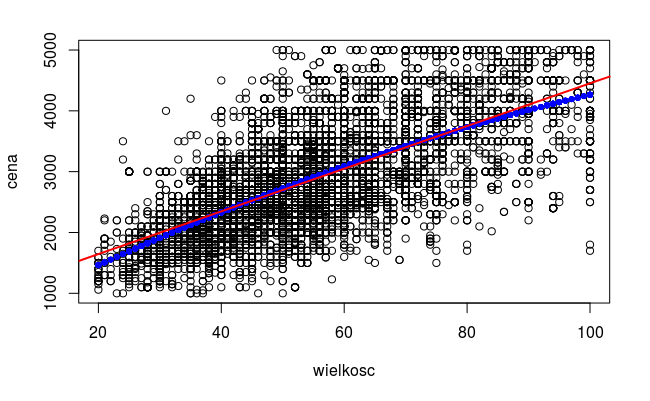

```r
abline(fit11, col = "red", lwd = 2)
```

Podsumowanie komunikuje nam, że wielkość w drugiej potędze jest istotnym czynnikiem. Jednakże widać na powyższym wykresie i po wartości Adjusted R^2 jak nieznacznie różnią się od siebie krzywe predykcyjne.

Z ciekawości sprawdźmy jak będzie wyglądał model dla jeszcze większego stopnia wielomianu.

```r
plot(cena~wielkosc, dane)
fit22 <-
  lm(cena~poly(wielkosc, 6), dane)
summary(fit22)
```

```
Call:
lm(formula = cena ~ poly(wielkosc, 6), data = dane)

Residuals:
     Min       1Q   Median       3Q      Max
-2218.47  -390.43   -52.45   351.51  2332.68

Coefficients:
                    Estimate Std. Error t value Pr(>|t|)
(Intercept)         2843.019      5.905 481.430  < 2e-16 ***
poly(wielkosc, 6)1 55517.286    590.684  93.988  < 2e-16 ***
poly(wielkosc, 6)2 -4634.669    590.684  -7.846 4.72e-15 ***
poly(wielkosc, 6)3 -3666.422    590.684  -6.207 5.61e-10 ***
poly(wielkosc, 6)4 -4240.237    590.684  -7.179 7.55e-13 ***
poly(wielkosc, 6)5 -1119.607    590.684  -1.895   0.0581 .
poly(wielkosc, 6)6   703.338    590.684   1.191   0.2338
---
Signif. codes:  0 ‘***’ 0.001 ‘**’ 0.01 ‘*’ 0.05 ‘.’ 0.1 ‘ ’ 1

Residual standard error: 590.7 on 9998 degrees of freedom
Multiple R-squared:  0.4735,    Adjusted R-squared:  0.4732
F-statistic:  1498 on 6 and 9998 DF,  p-value: < 2.2e-16
```

```r
points(dane$wielkosc, fitted(fit22), col = "green", pch = 20)
```

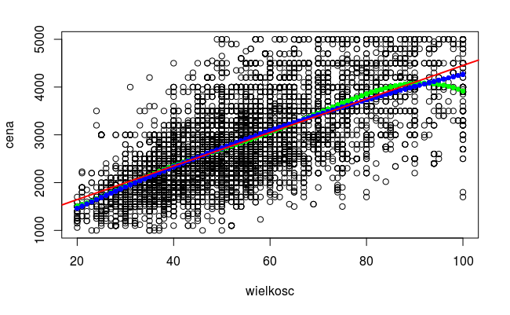

```r
points(dane$wielkosc, fitted(fit21), col = "blue", pch = 20)
abline(fit11, col = "red", lwd = 2)
```

```r
# contrast() - for qualitative predictors
```

Możemy zauważyć, że współczynnik 5 stopnia nie jest istotny dla modelu. Dodatkowo funkcja w prawym przedziale dziedziny zaczyna zbyt silnie dopasowywać się do danych (zwłaszcza na samym krańcu).

## Kroswalidacja

Tym razem do wyznaczenia błędu naszego modelu posłużymy się metodą kroswalidacji. W tym celu załadujemy odpowiednią bibliotekę ułatwiającą dalszą pracę.

```r
library(boot)
```

Najpierw wykorzystamy `LOOCV` czyli `Leave One Out Cross Validation`.

```r
LOOCV$delta
```

[output not shown]

```
[1] 354282 354282
```

`LOOCV` tworzy tyle modeli ile jest obserwacji w zestawie danych, za każdym razem pomijając jedeną z nich. Następnie określa błąd sprawdzając różnicę między pominiętą obserwacją a jej przewidywaniem wynikającym z powstałego modelu. Błąd ten określa wartość delta zwróconego obiektu. Pierwsza liczba jest po prostu błędem wyliczonym na podstawie całego danych, druga zaś koryguje ten błąd ze względu na fakt, iż zestaw danych uczących był mniejszy (w tym wypadku zawsze o jedną pozycję). W tym wypadku nie widać żadnej różnicy. Efekt ten będzie bardziej widoczny dla K krotnej kroswalidacji.

```r
loocv.glm <-
  function(fit) {
    h <- lm.influence(fit)$h
    mean((residuals(fit)/(1-h))^2)
  }

loocv.glm(fit31)
```

[output not shown]

Powodem dla którego metoda cv.glm nie korzysta docelowo z tej formuły jest fakt, że nie funkcjonuje ona w wypadku regresji logistycznej.

Teraz sprawdzimy jakie błędy będą towarzyszyć wielomianom kolejnych stopni i czy opłaca się je zastosować.

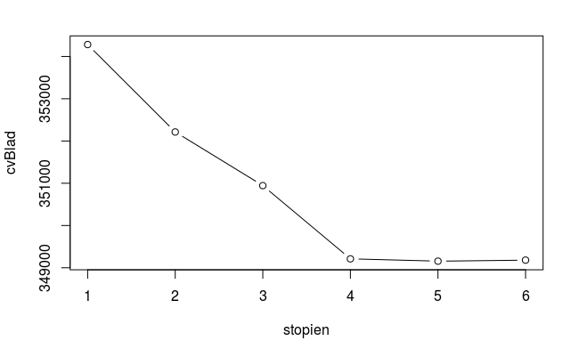

```r
# cvBlad <- rep(0, 6)
# stopien <- 1:6
# for (d in stopien) {
#   fit32 <- glm(cena~poly(wielkosc, d), data = dane)
#   cvBlad[d] <- loocv.glm(fit32)
# }
#
# plot(stopien, cvBlad)
cvBlad <-
  stopien %>%
  sapply(
    function(x) {
      fit32 <- glm(cena~poly(wielkosc, x), data = dane)
      loocv.glm(fit32)
    }
  )
plot(stopien, cvBlad, type = "b")
```

Na wykresie można zauważyć, że błąd przestaje maleć dla wielmianu 4 stopnia.

Teraz spróbujemy przeprowadzić K krotną kroswalidację. Standardowo za K przyjmuje się wartości 5 lub 10. W tym wypadku przyjmę tę większą.

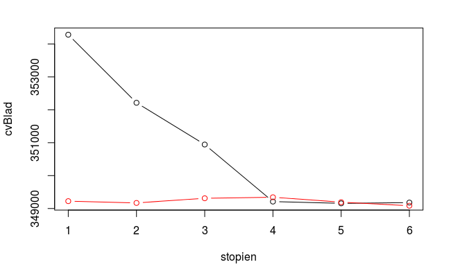

```r
cvBladK10 <-
  stopien %>%
  sapply(
    function(x) {
      cv.glm(dane, fit32, K = 10)$delta[1]
    }
  )
plot(stopien, cvBlad, type = "b")
lines(stopien, cvBladK10, type = "b", col = "red")
```

K krotna kroswalidacja jest bardziej stabilną metodą. W tym przypadku widać jak podpowiada nam, że już w zasadzie funkcja liniowa jest wystarczającym modelem.

## Dobór modelu z wieloma predykatami

Powyższy przykład pozwolił nam określić jaki stopień wielomianu jednego predykatu będzie odpowiedni dla naszego modelu. Tym razem chcemy jednak dobrać odpowiedni model z wieloma predykatami. Jakie są nasze opcje?

### Best Subset Regression

Metoda ta porównuje wszytkie możliwe modele regresji o wszystkich możliwych wielkościach (liczbie biorących udział w tworzeniu modelu predykatów) w poszukiwaniu najlepszego modelu dla każdego z rozmiarów. W sumie wykonuje 2^p modeli, gdzie p to lizcba predykatów (w naszym przypadku 2^11 czyli 2048) W osiągnięciu tego celu pomoże nam biblioteka `leaps`.

```r
fit41 <- regsubsets(cena~., dane, nvmax = 11)
sum41 <- summary(fit41)
sum41
```

```
Subset selection object
Call: regsubsets.formula(cena ~ ., dane, nvmax = 11)
39 Variables  (and intercept)
                                     Forced in Forced out
lokalizacjaBiałołęka, Warszawa           FALSE      FALSE
lokalizacjaBielany, Warszawa             FALSE      FALSE
lokalizacjaMokotów, Warszawa             FALSE      FALSE
lokalizacjaOchota, Warszawa              FALSE      FALSE
lokalizacjaPraga Północ, Warszawa        FALSE      FALSE
lokalizacjaPraga Południe, Warszawa      FALSE      FALSE
lokalizacjaRembertów, Warszawa           FALSE      FALSE
lokalizacjaŚródmieście, Warszawa         FALSE      FALSE
lokalizacjaTargówek, Warszawa            FALSE      FALSE
lokalizacjaUrsus, Warszawa               FALSE      FALSE
lokalizacjaUrsynów, Warszawa             FALSE      FALSE
```

[output cut: 174 more lines]

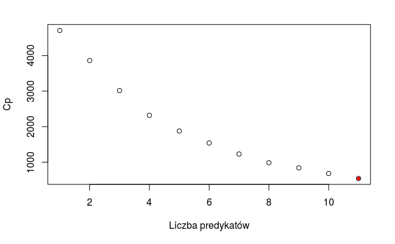

```r
plot(sum41$cp, xlab = "Liczba predykatów", ylab = "Cp")
points(11, sum41$cp[11], pch = 20, col = "red")
```

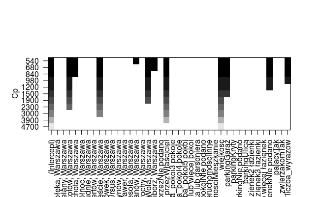

```r
plot(fit41, scale = "Cp")
```

```r
coef(fit41, 11)
```

```
                     (Intercept)     lokalizacjaMokotów, Warszawa      lokalizacjaOchota, Warszawa
                      450.545913                       476.235032                       349.124397
lokalizacjaŚródmieście, Warszawa     lokalizacjaWilanów, Warszawa        lokalizacjaWola, Warszawa
                      649.739130                       310.623299                       423.324692
   lokalizacjaŻoliborz, Warszawa     do_wynajecia_przezWłaściciel                         wielkosc
                      394.000726                      -222.266641                        32.679045
                    parkingGaraż        liczba_lazienekNie podano                   liczba_wyrazow
                      271.762260                       209.638385                         1.130164
```

Niestety, w tym wypadku nie widać czym charakteryzuje się ta metoda. Nie zakłada ona zagnieżdżania podzbiorów predykatów. Zagnieżdzanie polega na tym, że każdy kolejny większy model musi opierać się na czynnikach wchodzących w skład poprzedniego modelu. Tutaj mobłoby dojść do sytuacji, gdzie dla kilku pierwszych podzbiorów przy konkretnym czynniku występują gwiazdki, następnie zaś nie pojawiają się.

Cp jest miarą błędu predykcji. Jak widać w tym przypadku najmniejszy błąd występuje dla modelu o największej liczbie predykatów. Wcale nie musiało tak być i z większą liczbą czynników błąd mógłby zacząć rosnąć.

### Forward Stepwise Selection

Ta metodą jest jest “chciwa” w tym sensie, że zagnieżdza kolejne podzbiory czynników. Nie tworzy zatem każdej możliwej kombinacji predykatów. Już raz dobrany czynnik wykorzystywany jest w następnym modelu. Przy dobieraniu kolejnego predykatu metoda ta dobiera najlepszą opcję porównując tylko p modeli. Zatem ogółem liczba operacji wynosi około (p^2)/2 (w naszym przypadku około 60, czyli tylko 3% w porównaniu z poprzednią metodą.

```r
fit42 <- regsubsets(cena~., dane, nvmax = 11, method = "forward")
sum42 <- summary(fit42)
sum42
plot(sum42$cp, xlab = "Liczba predykatów", ylab = "Cp")
points(11, sum42$cp[11], pch = 20, col = "red")
plot(fit42, scale = "Cp")
coef(fit42, 11)
```

[output not shown]

### Backward Stepwise Selection

Metoda ta różni się od FSS tym, że zaczyna porównywać modele zbudowane na wszystkich predykatach i z każdym kolejnym krokiem odejmuję jeden z nich (najmniej istotny) z zestawu. Minusem tej metody jest to, że nie można użyć jej na zestawie danych gdzie występuje więcej kolumn niż wierszy.

```r
fit43 <- regsubsets(cena~., dane, nvmax = 11, method = "backward")
sum43 <- summary(fit43)
sum43
plot(sum43$cp, xlab = "Liczba predykatów", ylab = "Cp")
points(11, sum43$cp[11], pch = 20, col = "red")
plot(fit43, scale = "Cp")
coef(fit43, 11)
```

[output not shown]

### Walidacja

Tym razem podzielimy obserwacje na dwa zestawy - treningowy i walidacyjny.

```r
set.seed(44)
trening44 <- sample(1:nrow(dane), 9000)
fit44 <- regsubsets(cena~., dane[trening44, ], nvmax = 11, method = "forward")
```

```
1  linear dependencies found
```

```
Reordering variables and trying again:
```

Teraz dokonamy predykcji na obserwacjach z zestawu testowego.

```r
test44 <- model.matrix(cena~., dane[-trening44, ])
valBlad <-
  1:length(dane) %>%
  sapply(
    function(x) {
      coefi <- coef(fit44, id = x)
      pred <- test44[, names(coefi)]%*%coefi
      mean((dane$cena[-trening44]-pred)^2)
    }
  )
plot(
  sqrt(valBlad),
  ylim = c(400, 900),
  xlab = "Rozmiar modelu",
  ylab = "Średnia kwadratowa błędów",
  pch = 19,
  type = "b"
)
points(sqrt(fit44$rss[-1]/9000), col = "red", pch = 19, type = "b")
```

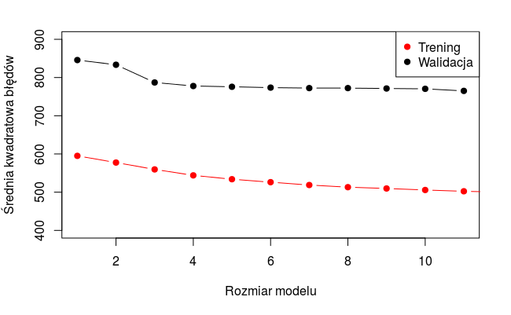

```r
legend("topright", legend = c("Trening", "Walidacja"), col = c("red", "black"), pch = 19)
```

Na powyższym wykresie można zauważyć, że pomimo konsekwentnego spadku błędu treningowego, już przy rozmiarze modelu wynoszącym 3 błąd walidacji wypłaszcza się.

Na koniec operacje prowadzące do otrzymania takiego rezultatu zostaną ubrane w jedna funkcję.

```r
predict.regsubsets <-
  function(obiekt, dane, id, ...) {
    form <- as.formula(obiekt$call[[2]])
    mat <- model.matrix(form, dane)
    coefi <- coef(obiekt, id = id)
    mat[, names(coefi)]%*%coefi
  }
```

### Kroswalidacja

Tym razem dobierzemy model korzystając z 10 krotnej kroswalidacji.

```r
set.seed(45)
folds <- sample(rep(1:10, length = nrow(dane)))
table(folds)
# cvBledy <-
#   1:10 %>%
#   sapply(
#     function (k) {
#       best.fit <- regsubsets(cena~., dane[folds!=k, ], nvmax = 11, method = "forward")
#       mapply(
#           function(K, i) {
#             pred <- predict(BEST.FIT, dane[folds==K, ], id = i)
#             mean((dane$cena[folds==K]-pred)^2)
#           },
#           k, 1:length(dane),
#           MoreArgs = list(BEST.FIT = best.fit)
#         )
#     }
#   )

cvBledy <- matrix(NA, 10, 11)
for (k in 1:10) {
  best.fit <- regsubsets(cena~., dane[folds!=k, ], nvmax = 11, method = "forward")
  for (i in 1:length(dane)) {
    pred <- predict.regsubsets(best.fit, dane[folds==k, ], id = i)
    cvBledy[k, i] <- mean((dane$cena[folds==k]-pred)^2)
  }
}
rmse.cv <- sqrt(apply(cvBledy, 2, mean))
# plot(
#   sqrt(valBlad),
#      ylim = c(400, 900),
#      xlab = "Rozmiar modelu",
#      ylab = "Średnia kwadratowa błędów",
#      pch = 19,
#      type = "b"
# )
# points(rmse.cv, col = "red", pch = 19, type = "b")
# legend("topright", legend = c("10 krotna Kroswalidacja", "Walidacja"), col = c("red", "black"), pch = 19)

plot(
  sqrt(valBlad),
  ylim = c(400, 900),
  xlab = "Rozmiar modelu",
  ylab = "Średnia kwadratowa błędów",
  pch = 19,
  type = "b"
)
points(sqrt(fit44$rss[-1]/9000), col = "red", pch = 19, type = "b")
points(rmse.cv, col = "blue", pch = 19, type = "b")
legend(
  "topright",
  legend = c("10 krotna Kroswalidacja", "Trening", "Walidacja"),
  col = c("blue", "red", "black"),
  pch = 19
)
```

[output not shown]